# Lab 1

```python
import csv
import numpy as np
import matplotlib.pyplot as plt
from statistics import *
```

```python
with open("weatherRaw.csv", "r", newline="") as file:
    wlist = list(csv.reader(file))

## Print in tabular way
for instance in wlist:
    for attr in instance:
        print("{:<15}".format(attr), end="")
    print()
```

```
sunny          85             85             FALSE          no
sunny          80             90             TRUE           no
overcast       83             86             FALSE          yes
rainy          70             96             FALSE          yes
rainy          68             80             FALSE          yes
rainy          65             70             TRUE           no
overcast       64             65             TRUE           yes
sunny          72             95             FALSE          no
sunny          69             70             FALSE          yes
rainy          75             80             FALSE          yes
sunny          75             70             TRUE           yes
overcast       72             90             TRUE           yes
overcast       81             75             FALSE          yes
rainy          71             91             TRUE           no
```

```python
## Print number of instances
print("Number of instances " + str(len(wlist)))
```

```
Number of instances 14
```

```python
## Temperature min, max, avg
wlist = np.array(wlist)
temp = wlist[:,1].astype('float')
print("Temperature minimum " + str(min(temp)))
print("Temperature maximum " + str(max(temp)))
print("Temperature mean " + str(mean(temp)))
```

```
Temperature minimum 64.0
Temperature maximum 85.0
Temperature mean 73.57142857142857
```

```python
## Humidity min, max, avg
hum = wlist[:,2].astype('float')
print("Humidity minimum " + str(min(hum)))
print("Humidity maximum " + str(max(hum)))
print("Humidity mean " + str(mean(hum)))
```

```
Humidity minimum 65.0
Humidity maximum 96.0
Humidity mean 81.64285714285714
```

```python
## Class breakdown
add = 0
for el in wlist:
    if el[4] == "yes":
        add += 1
print("Class breakdown\nYes: " + str(add) +"\nNo: " + str(len(wlist[:,1]) - add))
```

```
Class breakdown
Yes: 9
No: 5
```

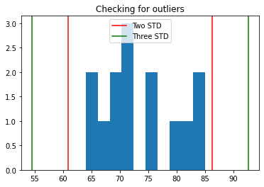

```python
## Temperature plot
plt.hist(temp)
oneStd = np.std(temp)
meanV = mean(temp)
plt.title("Checking for outliers")
plt.axvline(x=(meanV - 2*oneStd), label='Two STD', c="r")
plt.axvline(x=(meanV + 2*oneStd), c="r")
plt.axvline(x=(meanV - 3*oneStd), label='Three STD', c="g")
plt.axvline(x=(meanV + 3*oneStd), c="g")
plt.legend()
plt.show()
```

There are no clear outliers according to this histogram.

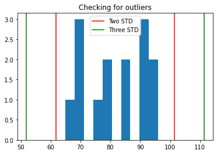

```python
## Humidity plot
plt.hist(hum)
oneStd = np.std(hum)
meanV = mean(hum)
plt.title("Checking for outliers")
plt.axvline(x=(meanV - 2*oneStd), label='Two STD', c="r")
plt.axvline(x=(meanV + 2*oneStd), c="r")
plt.axvline(x=(meanV - 3*oneStd), label='Three STD', c="g")
plt.axvline(x=(meanV + 3*oneStd), c="g")
plt.legend()
plt.show()
```

There are no clear outliers according to this histogram.

```python
with open("pima-indians-diabetes.csv", "r", newline="") as file:
    plist = list(csv.reader(file))

## Print in tabular way
for instance in plist:
    for attr in instance:
        print("{:<10}".format(attr), end="")
    print()
```

```
6         148       72        35        0         33.6      0.627     50        1
1         85        66        29        0         26.6      0.351     31        0
8         183       64        0         0         23.3      0.672     32        1
1         89        66        23        94        28.1      0.167     21        0
0         137       40        35        168       43.1      2.288     33        1
5         116       74        0         0         25.6      0.201     30        0
3         78        50        32        88        31        0.248     26        1
10        115       0         0         0         35.3      0.134     29        0
2         197       70        45        543       30.5      0.158     53        1
8         125       96        0         0         0         0.232     54        1
4         110       92        0         0         37.6      0.191     30        0
10        168       74        0         0         38        0.537     34        1
10        139       80        0         0         27.1      1.441     57        0
1         189       60        23        846       30.1      0.398     59        1
5         166       72        19        175       25.8      0.587     51        1
```

[output cut: 753 more lines]

```python
## Print number of instances
print("Number of instances " + str(len(plist)))
```

```
Number of instances 768
```

```python
## Times pregnant min, max, avg
plist = np.array(plist)
preg = plist[:,0].astype(int)
print("Times pregnant minimum " + str(min(preg)))
print("Times pregnant maximum " + str(max(preg)))
print("Times pregnant mean " + str(mean(preg)))
```

```
Times pregnant minimum 0
Times pregnant maximum 17
Times pregnant mean 3
```

```python
## Class breakdown
add = 0
for el in plist:
        add += int(el[8])
print("Class breakdown\nYes: " + str(add) +"\nNo: " + str(len(plist[:,8]) - add))
```

```
Class breakdown
Yes: 268
No: 500
```

```
Mean: 33.240885416666664
One StdV: 11.752572645994181
```

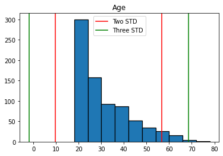

```python
## Age plot
data = plist[:,7].astype('float')
plt.hist(data, align='left', edgecolor='black', linewidth=1.2)
oneStd = np.std(data)
meanV = mean(data)
print("Mean: " + str(meanV))
print("One StdV: " + str(oneStd))
plt.title("Age")
plt.axvline(x=(meanV - 2*oneStd), label='Two STD', c="r")
plt.axvline(x=(meanV + 2*oneStd), c="r")
plt.axvline(x=(meanV - 3*oneStd), label='Three STD', c="g")
plt.axvline(x=(meanV + 3*oneStd), c="g")
plt.legend()
plt.show()
```

Although there are many values outside of 2 standard variations, these values aren't really outliers because it is feasable that women over 55 years old would have taken part in the questionnaire or the test to collect this data.

```
Mean: 20.536458333333332
One StdV: 15.941828626496939
```

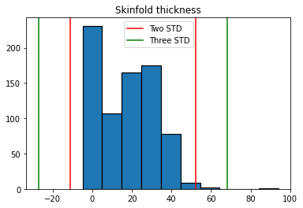

```python
## Skinfold thickness plot
data = plist[:,3].astype('float')
plt.hist(data, align='left', edgecolor='black', linewidth=1.2)
oneStd = np.std(data)
meanV = mean(data)
print("Mean: " + str(meanV))
print("One StdV: " + str(oneStd))
plt.title("Skinfold thickness")
plt.axvline(x=(meanV - 2*oneStd), label='Two STD', c="r")
plt.axvline(x=(meanV + 2*oneStd), c="r")
plt.axvline(x=(meanV - 3*oneStd), label='Three STD', c="g")
plt.axvline(x=(meanV + 3*oneStd), c="g")
plt.legend()
plt.show()
```

As we can see there are many instances where the skinfold is 0mm and this isn't normal. Therefore, this values must be outliers despite not being outside of 2 standard deviations.

```
Mean: 31.992578125
One StdV: 7.87902573154013
```

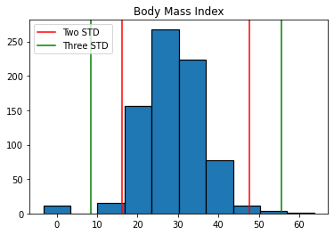

```python
## BMI plot
data = plist[:,5].astype('float')
plt.hist(data, align='left', edgecolor='black', linewidth=1.2)
oneStd = np.std(data)
meanV = mean(data)
print("Mean: " + str(meanV))
print("One StdV: " + str(oneStd))
plt.title("Body Mass Index")
plt.axvline(x=(meanV - 2*oneStd), label='Two STD', c="r")
plt.axvline(x=(meanV + 2*oneStd), c="r")
plt.axvline(x=(meanV - 3*oneStd), label='Three STD', c="g")
plt.axvline(x=(meanV + 3*oneStd), c="g")
plt.legend()
plt.show()
```

There are some more clear outliers here because you can't have 0 BMI. It is very likely that these instances didn't have their BMI measured and a 0 was inserted instead. There are some unlikely BMI's outside of 2 standard deviations but they are possible so these instances should be taken into consideration.

```
Mean: 3
One StdV: 3.3673836124089958
```

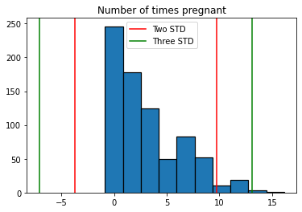

```python
## Number of times pregnant plot
plt.hist(preg, align='left', edgecolor='black', linewidth=1.2)
oneStd = np.std(preg)
meanV = mean(preg)
print("Mean: " + str(meanV))
print("One StdV: " + str(oneStd))
plt.title("Number of times pregnant")
plt.axvline(x=(meanV - 2*oneStd), label='Two STD', c="r")
plt.axvline(x=(meanV + 2*oneStd), c="r")
plt.axvline(x=(meanV - 3*oneStd), label='Three STD', c="g")
plt.axvline(x=(meanV + 3*oneStd), c="g")
plt.legend()
plt.show()
```

Although the values to the right of 2 STDs are not very common nowadays, they are possible. Therefore, these instances should not be deleted from the dataset. It is likely that if we looked into the instances with a higher number of pregnancies, they would probably be associated with the older women that took part in the survey.